# Latent Factor Analysis vs Mixture Models for Binary Data

Understanding Gradient Flow and Model Differences

Tutorial

2026-01-30

# Introduction

This tutorial explores two different approaches to modeling binary data with latent structure:

1. **Latent Factor Analysis (LFA)**: $P(Y=1) = \sigma(\sum_k l_k \times f_k)$ (sigmoid **outside**)
2. **Mixture Model**: $P(Y=1) = \sum_k \pi_k \times \sigma(f_k)$ (sigmoid **inside**)

**Key Question**: Why does the mixture model require higher learning rates?

# Setup

```r
library(tidyverse)
library(gridExtra)
library(viridis)
library(patchwork)

# Sigmoid function
sigmoid <- function(x) 1 / (1 + exp(-x))

# Softmax function
softmax <- function(x) {
  exp_x <- exp(x - max(x))  # Numerical stability
  exp_x / sum(exp_x)
}
```

# Part 1: Generate Data from TRUE Mixture Model

Let’s generate data where we KNOW the ground truth is a mixture model.

```r
# Parameters
N <- 500      # Number of samples
D <- 15       # Number of features (diseases)
K <- 3        # Number of latent components (signatures)

# TRUE mixture weights for each person (sum to 1)
# Each person is a mixture of K disease signatures
theta_true <- matrix(0, N, K)
for (i in 1:N) {
  theta_true[i, ] <- as.numeric(MCMCpack::rdirichlet(1, alpha = rep(2, K)))
}

# TRUE component probabilities for each signature
# Signature k has different disease probabilities
phi_true <- matrix(runif(K * D, min = -3, max = -1), K, D)  # Logits
p_true <- sigmoid(phi_true)  # Probabilities

# Generate TRUE probabilities for each person-disease
pi_true <- theta_true %*% p_true  # N x D

# Generate binary outcomes
Y <- matrix(rbinom(N * D, 1, pi_true), N, D)

# Summary
cat("Data dimensions:", N, "samples x", D, "features\n")
```

```
## Data dimensions: 500 samples x 15 features
```

```r
cat("True prevalence range:", round(min(pi_true), 3), "-", round(max(pi_true), 3), "\n")
```

```
## True prevalence range: 0.055 - 0.247
```

```r
cat("Observed sparsity:", round(mean(Y), 3), "\n")
```

```
## Observed sparsity: 0.145
```

## Visualize True Structure

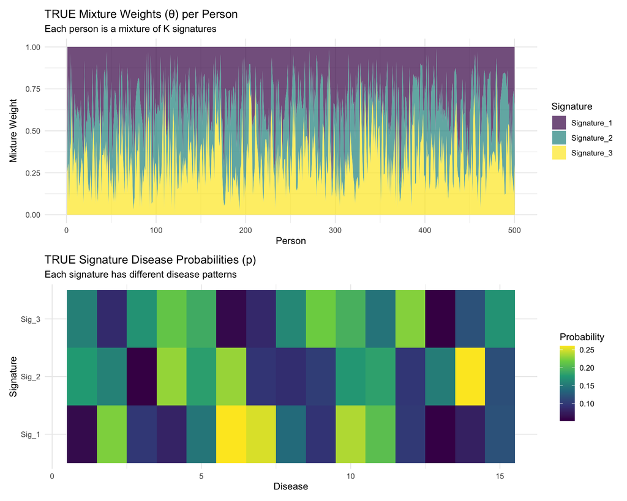

```r
# Plot 1: True mixture weights
df_theta <- as.data.frame(theta_true)
colnames(df_theta) <- paste0("Signature_", 1:K)
df_theta$Person <- 1:N

p1 <- df_theta %>%
  pivot_longer(-Person, names_to = "Signature", values_to = "Weight") %>%
  ggplot(aes(x = Person, y = Weight, fill = Signature)) +
  geom_area(alpha = 0.7) +
  scale_fill_viridis_d() +
  labs(title = "TRUE Mixture Weights (θ) per Person",
       subtitle = "Each person is a mixture of K signatures",
       y = "Mixture Weight") +
  theme_minimal()

# Plot 2: True signature probabilities
df_p <- as.data.frame(t(p_true))
colnames(df_p) <- paste0("Sig_", 1:K)
df_p$Disease <- 1:D

p2 <- df_p %>%
  pivot_longer(-Disease, names_to = "Signature", values_to = "Probability") %>%
  ggplot(aes(x = Disease, y = Signature, fill = Probability)) +
  geom_tile() +
  scale_fill_viridis_c() +
  labs(title = "TRUE Signature Disease Probabilities (p)",
       subtitle = "Each signature has different disease patterns") +
  theme_minimal()

p1 / p2
```

# Part 2: Understanding the Gradient Flow Issue

## Key Insight: Sigmoid Derivative

The derivative of sigmoid determines gradient strength:

$$\sigma'(x) = \sigma(x) \times (1 -
\sigma(x))$$

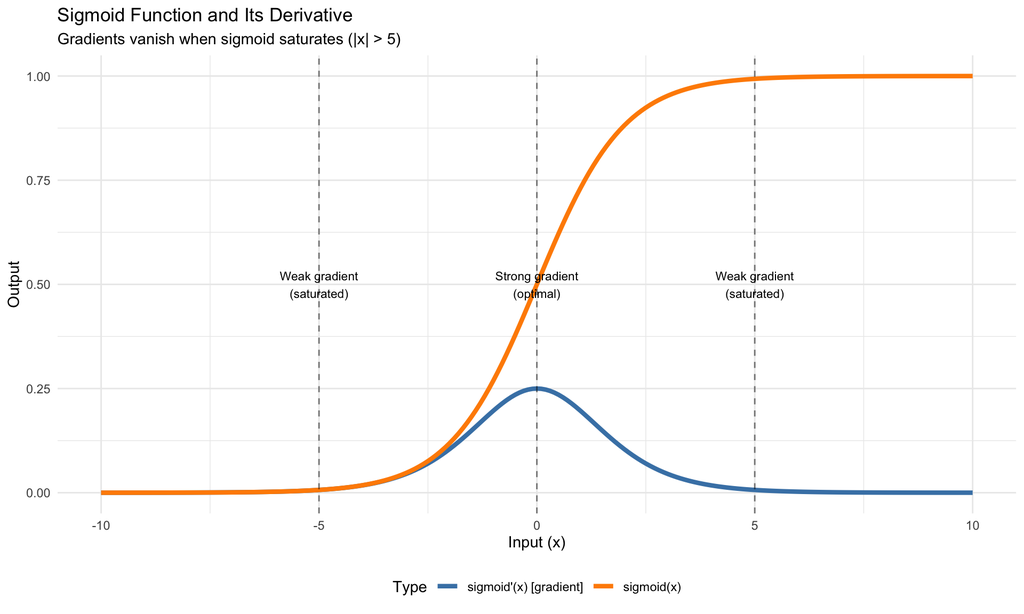

```r
x_vals <- seq(-10, 10, by = 0.1)
sigmoid_vals <- sigmoid(x_vals)
sigmoid_deriv <- sigmoid_vals * (1 - sigmoid_vals)

df_sig <- data.frame(
  x = rep(x_vals, 2),
  y = c(sigmoid_vals, sigmoid_deriv),
  Type = rep(c("sigmoid(x)", "sigmoid'(x) [gradient]"), each = length(x_vals))
)

ggplot(df_sig, aes(x = x, y = y, color = Type)) +
  geom_line(linewidth = 1.5) +
  geom_vline(xintercept = c(-5, 0, 5), linetype = "dashed", alpha = 0.5) +
  annotate("text", x = -5, y = 0.5, label = "Weak gradient\n(saturated)", size = 3) +
  annotate("text", x = 0, y = 0.5, label = "Strong gradient\n(optimal)", size = 3) +
  annotate("text", x = 5, y = 0.5, label = "Weak gradient\n(saturated)", size = 3) +
  scale_color_manual(values = c("steelblue", "darkorange")) +
  labs(title = "Sigmoid Function and Its Derivative",
       subtitle = "Gradients vanish when sigmoid saturates (|x| > 5)",
       x = "Input (x)", y = "Output") +
  theme_minimal() +
  theme(legend.position = "bottom")
```

**Key Observation**: - When input is near 0: gradient ≈ 0.25 (good!) - When input is ±5: gradient ≈ 0.01 (very weak!) - When input is ±10: gradient ≈ 0.0001 (vanishing!)

# Part 3: Model Fitting - Simplified Approach

Let’s fit both models using gradient descent and track the learning dynamics.

## Model 1: Latent Factor Analysis (LFA)

$$P(Y_{nd} = 1) = \sigma\left(\sum_k
l_{nk} \times f_{kd}\right)$$

```r
fit_lfa <- function(Y, K, lr = 0.01, n_iter = 500, verbose = FALSE) {
  N <- nrow(Y)
  D <- ncol(Y)

  # Initialize parameters (small random)
  L <- matrix(rnorm(N * K, sd = 0.1), N, K)  # Loadings
  F_mat <- matrix(rnorm(K * D, sd = 0.1), K, D)  # Factors

  losses <- numeric(n_iter)
  grad_norms <- numeric(n_iter)

  for (iter in 1:n_iter) {
    # Forward pass
    eta <- L %*% F_mat  # N x D
    pi_pred <- sigmoid(eta)

    # Loss (binary cross-entropy)
    eps <- 1e-8
    pi_pred <- pmax(pmin(pi_pred, 1 - eps), eps)
    loss <- -mean(Y * log(pi_pred) + (1 - Y) * log(1 - pi_pred))
    losses[iter] <- loss

    # Gradients
    grad_pi <- (pi_pred - Y) / (N * D)  # Average over all
    grad_eta <- grad_pi * pi_pred * (1 - pi_pred)  # Sigmoid derivative

    grad_L <- grad_eta %*% t(F_mat)
    grad_F <- t(L) %*% grad_eta

    grad_norms[iter] <- sqrt(mean(grad_L^2) + mean(grad_F^2))

    # Update
    L <- L - lr * grad_L
    F_mat <- F_mat - lr * grad_F

    if (verbose && iter %% 100 == 0) {
      cat(sprintf("Iter %d: Loss = %.4f, Grad = %.4f\n", iter, loss, grad_norms[iter]))
    }
  }

  list(L = L, F = F_mat, losses = losses, grad_norms = grad_norms)
}
```

## Model 2: Mixture Model

$$P(Y_{nd} = 1) = \sum_k \theta_{nk}
\times \sigma(\phi_{kd})$$

where $\theta_n = \text{softmax}(\lambda_n)$

```r
fit_mixture <- function(Y, K, lr = 0.01, n_iter = 500, verbose = FALSE) {
  N <- nrow(Y)
  D <- ncol(Y)

  # Initialize parameters (small random)
  lambda <- matrix(rnorm(N * K, sd = 0.1), N, K)  # Unconstrained
  phi <- matrix(rnorm(K * D, sd = 0.1), K, D)     # Logits

  losses <- numeric(n_iter)
  grad_norms <- numeric(n_iter)

  for (iter in 1:n_iter) {
    # Forward pass
    theta <- t(apply(lambda, 1, softmax))  # N x K (mixture weights)
    p <- sigmoid(phi)  # K x D (component probabilities)
    pi_pred <- theta %*% p  # N x D

    # Loss (binary cross-entropy)
    eps <- 1e-8
    pi_pred <- pmax(pmin(pi_pred, 1 - eps), eps)
    loss <- -mean(Y * log(pi_pred) + (1 - Y) * log(1 - pi_pred))
    losses[iter] <- loss

    # Gradients
    grad_pi <- (pi_pred - Y) / (N * D)

    # Gradient for phi (through sigmoid)
    grad_p <- t(theta) %*% grad_pi  # K x D
    grad_phi <- grad_p * p * (1 - p)  # Sigmoid derivative

    # Gradient for lambda (through softmax)
    grad_theta <- grad_pi %*% t(p)  # N x K

    # Softmax gradient (simplified - diagonal approximation)
    grad_lambda <- grad_theta * theta * (1 - theta)

    grad_norms[iter] <- sqrt(mean(grad_lambda^2) + mean(grad_phi^2))

    # Update
    lambda <- lambda - lr * grad_lambda
    phi <- phi - lr * grad_phi

    if (verbose && iter %% 100 == 0) {
      cat(sprintf("Iter %d: Loss = %.4f, Grad = %.4f\n", iter, loss, grad_norms[iter]))
    }
  }

  list(lambda = lambda, phi = phi, losses = losses, grad_norms = grad_norms)
}
```

# Part 4: Compare Models at Different Learning Rates

```r
learning_rates <- c(0.001, 0.005, 0.01, 0.03)
results <- list()

for (lr in learning_rates) {
  cat("\n=== Learning Rate:", lr, "===\n")

  cat("Fitting LFA...\n")
  lfa_fit <- fit_lfa(Y, K = K, lr = lr, n_iter = 500, verbose = FALSE)

  cat("Fitting Mixture...\n")
  mix_fit <- fit_mixture(Y, K = K, lr = lr, n_iter = 500, verbose = FALSE)

  results[[as.character(lr)]] <- list(
    lr = lr,
    lfa = lfa_fit,
    mixture = mix_fit
  )

  cat(sprintf("Final Loss - LFA: %.4f, Mixture: %.4f\n",
              tail(lfa_fit$losses, 1), tail(mix_fit$losses, 1)))
}
```

```
##
## === Learning Rate: 0.001 ===
## Fitting LFA...
## Fitting Mixture...
## Final Loss - LFA: 0.6933, Mixture: 0.6945
##
## === Learning Rate: 0.005 ===
## Fitting LFA...
## Fitting Mixture...
## Final Loss - LFA: 0.6931, Mixture: 0.6930
##
## === Learning Rate: 0.01 ===
## Fitting LFA...
## Fitting Mixture...
## Final Loss - LFA: 0.6932, Mixture: 0.6957
##
## === Learning Rate: 0.03 ===
## Fitting LFA...
## Fitting Mixture...
## Final Loss - LFA: 0.6932, Mixture: 0.6856
```

## Visualize Training Dynamics

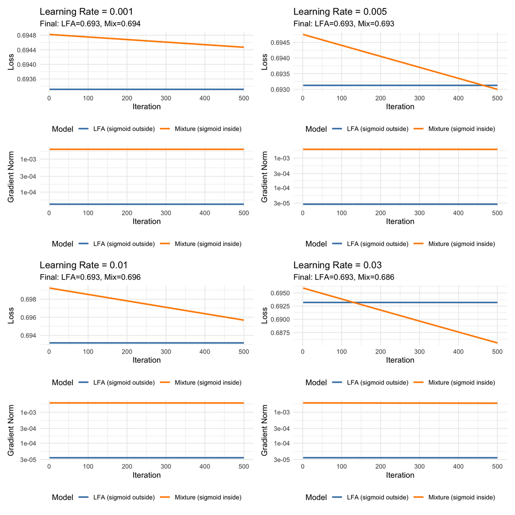

```r
plot_list <- list()

for (i in seq_along(learning_rates)) {
  lr <- learning_rates[i]
  res <- results[[as.character(lr)]]

  # Loss plot
  df_loss <- data.frame(
    Iteration = rep(1:500, 2),
    Loss = c(res$lfa$losses, res$mixture$losses),
    Model = rep(c("LFA (sigmoid outside)", "Mixture (sigmoid inside)"), each = 500)
  )

  p_loss <- ggplot(df_loss, aes(x = Iteration, y = Loss, color = Model)) +
    geom_line(linewidth = 1) +
    scale_color_manual(values = c("steelblue", "darkorange")) +
    scale_y_log10() +
    labs(title = paste0("Learning Rate = ", lr),
         subtitle = paste0("Final: LFA=", round(tail(res$lfa$losses, 1), 3),
                          ", Mix=", round(tail(res$mixture$losses, 1), 3))) +
    theme_minimal() +
    theme(legend.position = "bottom")

  # Gradient norm plot
  df_grad <- data.frame(
    Iteration = rep(1:500, 2),
    Gradient = c(res$lfa$grad_norms, res$mixture$grad_norms),
    Model = rep(c("LFA (sigmoid outside)", "Mixture (sigmoid inside)"), each = 500)
  )

  p_grad <- ggplot(df_grad, aes(x = Iteration, y = Gradient, color = Model)) +
    geom_line(linewidth = 1) +
    scale_color_manual(values = c("steelblue", "darkorange")) +
    scale_y_log10() +
    labs(y = "Gradient Norm") +
    theme_minimal() +
    theme(legend.position = "bottom")

  plot_list[[i]] <- p_loss / p_grad
}

wrap_plots(plot_list, ncol = 2)
```